# Predicting Customer Churn

## Telecom Customer Churn

All of the attributes except for attribute churn is the aggregated data of the first 9 months. The churn labels are the state of the customers at the end of 12 months. The three months is the designated planning gap.

## Business Problem

A competitor has recently entered the market and is offering an attractive plan to new customers. The telecom company is worried that this competitor may start attracting its customers.

You have access to a dataset of the company's customers, including whether customers churned. The telecom company wants to know whether you can use this data to predict whether a customer will churn. They also want to know what factors increase the probability that a customer churns.

You will need to prepare a report that is accessible to a broad audience.

```python
#Importing librabries
import numpy as np
import pandas as pd
import matplotlib.pyplot as plt
import seaborn as sns
```

## Data dictionary

- Call Failures: number of call failures
- Complains: binary (0: No complaint, 1: complaint)
- Subscription Length: total months of subscription
- Charge Amount: Ordinal attribute (0: lowest amount, 9: highest amount)
- Seconds of Use: total seconds of calls
- Frequency of use: total number of calls
- Frequency of SMS: total number of text messages
- Distinct Called Numbers: total number of distinct phone call
- Age Group: ordinal attribute (1: younger age, 5: older age)
- Tariff Plan: binary (1: Pay as you go, 2: contractual)
- Status: binary (1: active, 2: non-active)
- Churn: binary (1: churn, 0: non-churn) - Class label
- Customer Value: The calculated value of customer

```python
#Importing data
telco = pd.read_csv('C:/Users/Joseph/Desktop/MACHINE LEARNING/Marketing Analytics/Predicting customer churn in python/Portfolio Project/telco data.csv')
```

```python
#A preview of the data
telco.head()
```

|  | Call Failure | Complaints | Subscription Length | Charge Amount | Seconds of Use | Frequency of use | Frequency of SMS | Distinct Called Numbers | Age Group | Tariff Plan | Status | Age | Customer Value | Churn |
| --- | --- | --- | --- | --- | --- | --- | --- | --- | --- | --- | --- | --- | --- | --- |
| 0 | 8 | 0 | 38 | 0 | 4370 | 71 | 5 | 17 | 3 | 1 | 1 | 30 | 197.640 | 0 |
| 1 | 0 | 0 | 39 | 0 | 318 | 5 | 7 | 4 | 2 | 1 | 2 | 25 | 46.035 | 0 |
| 2 | 10 | 0 | 37 | 0 | 2453 | 60 | 359 | 24 | 3 | 1 | 1 | 30 | 1536.520 | 0 |
| 3 | 10 | 0 | 38 | 0 | 4198 | 66 | 1 | 35 | 1 | 1 | 1 | 15 | 240.020 | 0 |
| 4 | 3 | 0 | 38 | 0 | 2393 | 58 | 2 | 33 | 1 | 1 | 1 | 15 | 145.805 | 0 |

```python
telco.shape
```

[output not shown]

# Data Validation

```python
telco.info()
```

```
<class 'pandas.core.frame.DataFrame'>
RangeIndex: 1428 entries, 0 to 1427
Data columns (total 14 columns):
 #   Column                   Non-Null Count  Dtype
---  ------                   --------------  -----
 0   Call Failure             1428 non-null   int64
 1   Complaints               1428 non-null   int64
 2   Subscription Length      1428 non-null   int64
 3   Charge Amount            1428 non-null   int64
 4   Seconds of Use           1428 non-null   int64
 5   Frequency of use         1428 non-null   int64
 6   Frequency of SMS         1428 non-null   int64
 7   Distinct Called Numbers  1428 non-null   object
 8   Age Group                1428 non-null   int64
 9   Tariff Plan              1428 non-null   int64
 10  Status                   1428 non-null   int64
 11  Age                      1428 non-null   int64
 12  Customer Value           1428 non-null   float64
 13  Churn                    1428 non-null   int64
dtypes: float64(1), int64(12), object(1)
memory usage: 156.3+ KB
```

# Data Cleaning

```python
for col in telco.columns:
    pct_missing = np.mean(telco[col].isnull())
    print('{} - {}%'.format(col, pct_missing))
```

```
Call Failure - 0.0%
Complaints - 0.0%
Subscription Length - 0.0%
Charge Amount - 0.0%
Seconds of Use - 0.0%
Frequency of use - 0.0%
Frequency of SMS - 0.0%
Distinct Called Numbers - 0.0%
Age Group - 0.0%
Tariff Plan - 0.0%
Status - 0.0%
Age - 0.0%
Customer Value - 0.0%
Churn - 0.0%
```

# Exploratory Data Analysis

```python
telco['Churn'].value_counts()
```

```
0    1195
1     233
Name: Churn, dtype: int64
```

### 1. An idea of the relations between feautures

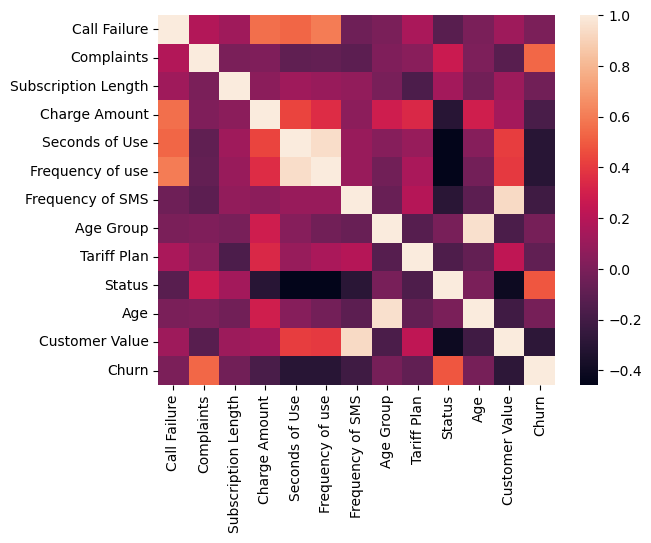

```python
sns.heatmap(telco.corr())
```

### 2. What percentage of the customers churn?

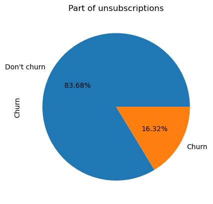

```python
## Part of the people that churn
percent = (telco['Churn'].value_counts()/telco['Churn'].value_counts().sum() * 100).values
telco['Churn'].value_counts().plot(kind='pie', labels=["Don't churn", "Churn"], autopct='%0.2f%%', title ='Part of unsubscriptions')
```

### 3. Do customer service complaints vary by age group?

[output not shown]

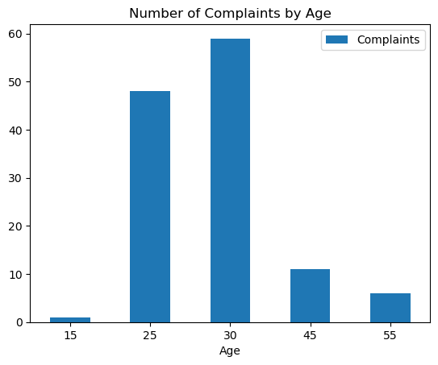

```python
telco[['Complaints','Age']].groupby('Age').sum().plot(kind='bar', title='Number of Complaints by Age')
plt.xticks(rotation=0)
```

### 4. Relation Between Age and Churn

[output not shown]

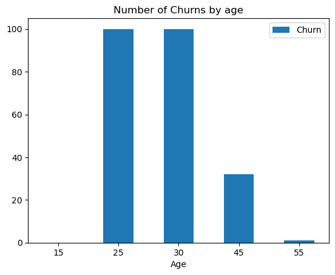

```python
telco[['Churn', 'Age']].groupby('Age').sum().plot(kind='bar', title='Number of Churns by age')
plt.xticks(rotation=0)
```

# Modeling

### 1. Preprocessing the data

```python
#Dropping features which don't add predictive power
telco.drop(['Distinct Called Numbers'], axis =1, inplace=True)
```

```python
from sklearn.decomposition import PCA
from sklearn.model_selection import train_test_split
from sklearn.preprocessing import StandardScaler

X = telco.drop('Churn', axis=1)
y = telco['Churn'].values.reshape(-1, 1)

scaler = StandardScaler()

X_scaled = scaler.fit_transform(X)

X_train, X_test, y_train, y_test = train_test_split(X_scaled, y, test_size=0.2, random_state=42)
```

### 2. Defining a score function

```python
from sklearn.metrics import classification_report, confusion_matrix
from sklearn.metrics import accuracy_score, roc_auc_score


def classification_score(y_pred, y_test, y_pred_pb):
    print('Accuracy of the model : ', round(accuracy_score(y_pred, y_test), 3), '\n')
    print('Area Under ROC Curve : ', roc_auc_score(y_test,y_pred_pb), '\n')
    print(classification_report(y_pred, y_test), '\n')
    print(confusion_matrix(y_pred, y_test))
```

### 3. Fitting to models

### A) Logistic regression model

```python
# Logistic Regression
from sklearn.linear_model import LogisticRegression

logreg = LogisticRegression()

logreg.fit(X_train, y_train)
y_pred = logreg.predict(X_test)
y_pred_pb = logreg.predict_proba(X_test)[:, 1]

classification_score(y_pred, y_test, y_pred_pb)
```

```
Accuracy of the model :  0.874

Area Under ROC Curve :  0.8920155478176371

              precision    recall  f1-score   support

           0       0.97      0.89      0.93       255
           1       0.45      0.77      0.57        31

    accuracy                           0.87       286
   macro avg       0.71      0.83      0.75       286
weighted avg       0.91      0.87      0.89       286


[[226  29]
 [  7  24]]
```

### B) Support vector machine model

```python
# SVC
from sklearn.svm import SVC

svc = SVC(probability=True)

svc.fit(X_train, y_train)
y_pred = svc.predict(X_test)
y_pred_pb = svc.predict_proba(X_test)[:, 1]

classification_score(y_pred, y_test, y_pred_pb)
```

```
Accuracy of the model :  0.892

Area Under ROC Curve :  0.935257915620698

              precision    recall  f1-score   support

           0       0.99      0.89      0.94       258
           1       0.47      0.89      0.62        28

    accuracy                           0.89       286
   macro avg       0.73      0.89      0.78       286
weighted avg       0.94      0.89      0.91       286


[[230  28]
 [  3  25]]
```

### C) Decision Tree Classifier Model

```python
# Decision Tree Classifier
from sklearn.tree import DecisionTreeClassifier

dtc = DecisionTreeClassifier()

dtc.fit(X_train, y_train)
y_pred = dtc.predict(X_test)
y_pred_pb = dtc.predict_proba(X_test)[:, 1]

classification_score(y_pred, y_test, y_pred_pb)
```

```
Accuracy of the model :  0.906

Area Under ROC Curve :  0.8346829702809943

              precision    recall  f1-score   support

           0       0.95      0.93      0.94       238
           1       0.70      0.77      0.73        48

    accuracy                           0.91       286
   macro avg       0.83      0.85      0.84       286
weighted avg       0.91      0.91      0.91       286


[[222  16]
 [ 11  37]]
```

### 4. Ranking features importance

```python
features_importance = pd.DataFrame(np.round(dtc.feature_importances_, 4) * 100, index=X.columns, columns=['Feature Importance (%)']).sort_values('Feature Importance (%)', ascending=False)

features_importance['Correlation to Churn'] = telco.corr().iloc[-1, :]
features_importance
```

|  | Feature Importance (%) | Correlation to Churn |
| --- | --- | --- |
| Complaints | 31.33 | 0.533797 |
| Seconds of Use | 15.94 | -0.300529 |
| Status | 13.69 | 0.486541 |
| Subscription Length | 10.88 | -0.031920 |
| Customer Value | 9.91 | -0.284996 |
| Frequency of use | 5.97 | -0.302636 |
| Call Failure | 5.38 | 0.000223 |
| Frequency of SMS | 4.22 | -0.216795 |
| Age Group | 1.47 | -0.017481 |
| Age | 1.21 | -0.016738 |
| Charge Amount | 0.00 | -0.172532 |
| Tariff Plan | 0.00 | -0.088092 |